# Intro to Data Science HW 7

##### Copyright Jeffrey Stanton, Jeffrey Saltz, and Jasmina Tacheva

### IST 687

### Due Date: 3/01/34

### Submission Date: 2/29/24

```r
# Enter your name here: Kent Roller
```

### Attribution statement: (choose only one and delete the rest)

```r
# 1. I did this homework by myself, with help from the book and the professor.
```

The chapter on **linear models** (“Lining Up Our Models”) introduces **linear predictive modeling** using the tool known as **multiple regression**. The term “multiple regression” has an odd history, dating back to an early scientific observation of a phenomenon called **“regression to the mean.”** These days, multiple regression is just an interesting name for using **linear modeling** to assess the **connection between one or more predictor variables and an outcome variable**.

In this exercise, you will **predict Ozone air levels from three predictors**.

1. We will be using the **airquality** data set available in R. Copy it into a dataframe called **air** and use the appropriate functions to **summarize the data**.

```r
# Loading dataset into a dataframe
air<-airquality
# Using built in R function to look at structure of df
str(air)
```

```
## 'data.frame':    153 obs. of  6 variables:
##  $ Ozone  : int  41 36 12 18 NA 28 23 19 8 NA ...
##  $ Solar.R: int  190 118 149 313 NA NA 299 99 19 194 ...
##  $ Wind   : num  7.4 8 12.6 11.5 14.3 14.9 8.6 13.8 20.1 8.6 ...
##  $ Temp   : int  67 72 74 62 56 66 65 59 61 69 ...
##  $ Month  : int  5 5 5 5 5 5 5 5 5 5 ...
##  $ Day    : int  1 2 3 4 5 6 7 8 9 10 ...
```

```r
# Loading tidyverse to be able to use contained functions
library(tidyverse)
# Using glimpse() to look at the structure of the df
glimpse(air)
```

```
## Rows: 153
## Columns: 6
## $ Ozone   <int> 41, 36, 12, 18, NA, 28, 23, 19, 8, NA, 7, 16, 11, 14, 18, 14, …
## $ Solar.R <int> 190, 118, 149, 313, NA, NA, 299, 99, 19, 194, NA, 256, 290, 27…
## $ Wind    <dbl> 7.4, 8.0, 12.6, 11.5, 14.3, 14.9, 8.6, 13.8, 20.1, 8.6, 6.9, 9…
## $ Temp    <int> 67, 72, 74, 62, 56, 66, 65, 59, 61, 69, 74, 69, 66, 68, 58, 64…
## $ Month   <int> 5, 5, 5, 5, 5, 5, 5, 5, 5, 5, 5, 5, 5, 5, 5, 5, 5, 5, 5, 5, 5,…
## $ Day     <int> 1, 2, 3, 4, 5, 6, 7, 8, 9, 10, 11, 12, 13, 14, 15, 16, 17, 18,…
```

```r
# Using built in R function summary() to get fivenum for each variable in df
summary(air)
```

```
##      Ozone           Solar.R           Wind             Temp
##  Min.   :  1.00   Min.   :  7.0   Min.   : 1.700   Min.   :56.00
##  1st Qu.: 18.00   1st Qu.:115.8   1st Qu.: 7.400   1st Qu.:72.00
##  Median : 31.50   Median :205.0   Median : 9.700   Median :79.00
##  Mean   : 42.13   Mean   :185.9   Mean   : 9.958   Mean   :77.88
##  3rd Qu.: 63.25   3rd Qu.:258.8   3rd Qu.:11.500   3rd Qu.:85.00
##  Max.   :168.00   Max.   :334.0   Max.   :20.700   Max.   :97.00
##  NA's   :37       NA's   :7
##      Month            Day
##  Min.   :5.000   Min.   : 1.0
##  1st Qu.:6.000   1st Qu.: 8.0
##  Median :7.000   Median :16.0
##  Mean   :6.993   Mean   :15.8
##  3rd Qu.:8.000   3rd Qu.:23.0
##  Max.   :9.000   Max.   :31.0
##
```

2. In the analysis that follows, **Ozone** will be considered as the **outcome variable**, and **Solar.R**, **Wind**, and **Temp** as the **predictors**. Add a comment to briefly explain the outcome and predictor variables in the dataframe using **?airquality**.

```r
?airquality
```

```
## starting httpd help server ... done
```

```r
# Ozone(Y variable): Mean ozone in ppb from 1300 to 1500 hours at Roosevelt Island taken daily from May 1 to Sep 30 1973.(all measurements same calendar schedule)
# Solar.R(X1 variable): Solar radiation in Langleys in the frequency band 4000-7000 Angstroms from 0800 to 1200 hours at Central Park.
# Wind (X2 variable): Average wind speed in mph at 0700 and 1000 hours at La Guardia Airport
# Temp (X3 variable): Maximum daily temperatures in degrees Fahrenheit at La Guardia Airport
```

3. Inspect the outcome and predictor variables – are there any missing values? Show the code you used to check for that.

```r
sum(is.na(air$Ozone))
```

```
## [1] 37
```

```r
sum(is.na(air$Solar.R))
```

```
## [1] 7
```

```r
sum(is.na(air$Wind))
```

```
## [1] 0
```

```r
sum(is.na(air$Temp))
```

```
## [1] 0
```

```r
# There are missing values in the Ozone variable and in the Solar.R variable, Wind and Temp have no NA observations
```

4. Use the **na_interpolation()** function from the **imputeTS package** (remember this was used in a previous HW) to fill in the missing values in each of the 4 columns. Make sure there are no more missing values using the commands from Step C.

```r
library(imputeTS)
air$Ozone<-na_interpolation(air$Ozone)
air$Solar.R<-na_interpolation(air$Solar.R)
```

```r
sum(is.na(air$Ozone))
```

```
## [1] 0
```

```r
sum(is.na(air$Solar.R))
```

```
## [1] 0
```

5. Create **3 bivariate scatterplots (X-Y) plots** (using ggplot), for each of the predictors with the outcome. **Hint:** In each case, put **Ozone on the Y-axis**, and a **predictor on the X-axis**. Add a comment to each, describing the plot and explaining whether there appears to be a **linear relationship** between the outcome variable and the respective predictor.

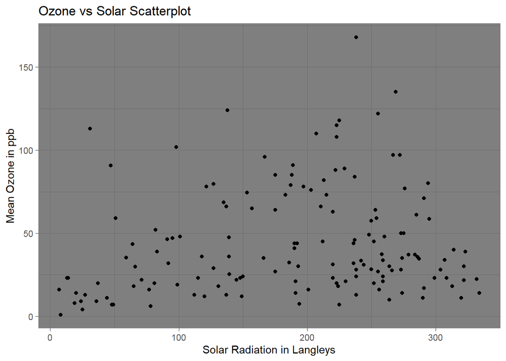

```r
ozone.vs.solarr<- ggplot(air, aes(x=Solar.R, y=Ozone)) + geom_point() + theme_dark() + labs(x="Solar Radiation in Langleys", y="Mean Ozone in ppb", title="Ozone vs Solar Scatterplot")

ozone.vs.solarr
```

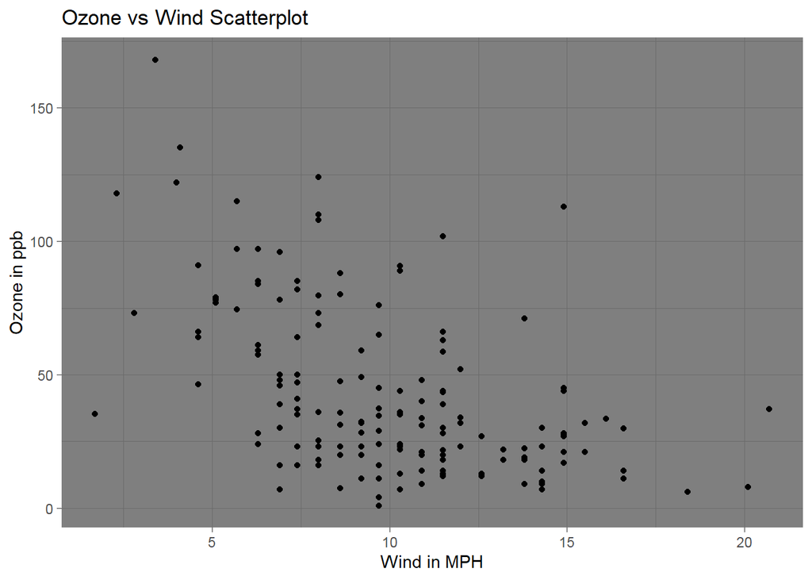

```r
# For Ozone vs Solar Radiation we see a very very weak linear relationship. And really I hesitate to call it linear at all, as it is possible to achieve the same Ozone with any level of Solar, however, there is a slight upward curve. I would expect this to potentially be significant(very small chance) but with a very small coefficient. A higher level of solar leads to an increased probablity of measuring a higher level of ozone.

ozone.vs.wind<-ggplot(air, aes(x=Wind, y=Ozone)) + geom_point() + theme_dark() + labs(x="Wind in MPH", y="Ozone in ppb", title="Ozone vs Wind Scatterplot")

ozone.vs.wind
```